# Statistical analysis of seed traits measured within the rice Global MAGIC population

```r
require(stringr)
require(data.table)
```

```r
require(ggplot2)
require(plyr)
require(dplyr)
require(tidyr)
require(dlookr)
require(tibble)
require(reshape2)
require(gridExtra)
require(grid)
require(ggfortify)
require(Hmisc)
require(GGally)
require(ggstatsplot)
require(nortest)
require(lsmeans)
require(rstatix)
require(ggcorrplot)
#let's load the phenotypic measurements obtained with the PlantCV pipeline
ww.geno.all <- read.csv("WW_Samples_ALLPhenotypes_Jan30_2020.csv")

#let's select the colummn that we need and convert pixels to mm based on the convertion factor for images with a 300 dpi resolution

ww.geno.all.clean <- ww.geno.all %>%
  select(Label_Phenotyping, Seed_ID, Genotype, Treatment, Number, image, timestamp, filename, ellipse_eccentricity, ellipse_minor_axis, ellipse_major_axis, convex_hull_area, perimeter, solidity, area, longest_path, convex_hull_vertices) %>%
  mutate(Area = area *0.085,
         CH.Area = convex_hull_area * 0.085,
         Perimeter = perimeter * 0.085,
         Longest.Path = longest_path * 0.085,
         Major.Axis = ellipse_major_axis * 0.085,
         Minor.Axis = ellipse_minor_axis * 0.085) %>%
  rename(Environment = Treatment,
         CH.Vertices = convex_hull_vertices,
         Eccentricity = ellipse_eccentricity,
         Solidity = solidity)

#write.csv(ww.geno.all.clean, "WW_Samples_ALLPhenotypes_Metrics_mm_Feb14_2020.csv", row.names = F)

ds.geno.all <- read.csv("DS_Samples__ALLPhenotypes_Jan30_2020.csv")

ds.geno.all.clean <- ds.geno.all %>%
  select(Label_Phenotyping, Seed_ID, Genotype, Treatment, Number, image, timestamp, filename, ellipse_eccentricity, ellipse_minor_axis, ellipse_major_axis, convex_hull_area, perimeter, solidity, area, longest_path, convex_hull_vertices) %>%
  mutate(Area = area *0.085,
         CH.Area = convex_hull_area * 0.085,
         Perimeter = perimeter * 0.085,
         Longest.Path = longest_path * 0.085,
         Major.Axis = ellipse_major_axis * 0.085,
         Minor.Axis = ellipse_minor_axis * 0.085) %>%
  rename(Environment = Treatment,
         CH.Vertices = convex_hull_vertices,
         Eccentricity = ellipse_eccentricity,
         Solidity = solidity)

#write.csv(ds.geno.all.clean, "DS_Samples__ALLPhenotypes_Metrics_mm_Feb14_2020.csv", row.names = F)
```

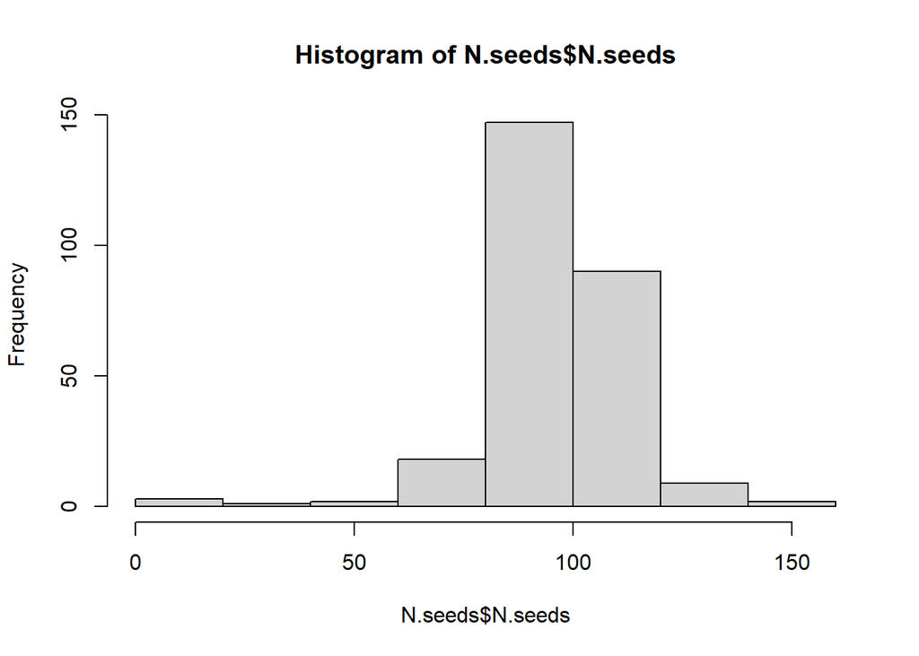

```r
ww.metrics <- ww.geno.all.clean %>%
  select(-c(Seed_ID, image, timestamp, ellipse_minor_axis, ellipse_major_axis, area, convex_hull_area, perimeter, longest_path))

#write.csv(ww.metrics, "WW_Samples_onlyPheno_Converted_mm_Feb14_2020.csv", row.names = F)

N.seeds <- data.frame(table(ww.metrics$Label_Phenotyping))
colnames(N.seeds) <- c("Label_Phenotyping", "N.seeds")
hist(N.seeds$N.seeds)
```

```r
summary(N.seeds$N.seeds)
```

```
##    Min. 1st Qu.  Median    Mean 3rd Qu.    Max.
##    3.00   90.00   98.00   96.91  106.00  145.00
```

```r
#(95% confidence interval)

N.seeds.CI.ww <- N.seeds %>%
  summarise(mean = mean(N.seeds, na.rm = TRUE),
            sd = sd(N.seeds, na.rm = TRUE),
            n = n()) %>%
  mutate(se = sd / sqrt(n),
         lower.ci = mean - qt(1 - (0.05 / 2), n - 1) * se,
         upper.ci = mean + qt(1 - (0.05 / 2), n - 1) * se)

N.seeds.CI.ww
```

| mean | sd | n | se | lower.ci | upper.ci |
| --- | --- | --- | --- | --- | --- |
| 96.90809 | 16.76566 | 272 | 1.016568 | 94.90671 | 98.90946 |

To identify and remove seedoutliers per sample, I first try different methods. Then, I decided to visualize sample boxplots and then define upper and lower cutoff that will remove those seeds touching on the scanner and identified as a single object (large value of seed area) and seeds fragmented in small pieces identified as separated objects (very small seed area values).

```r
summary(ww.metrics$Area)
```

```
##    Min. 1st Qu.  Median    Mean 3rd Qu.    Max.
##   2.125 156.740 175.865 174.891 194.055 393.040
```

```r
#identify outliers using the boxplot.stats function
outlier_values <- boxplot.stats(ww.metrics$area_inmm2)$out

# outlier values.
length(outlier_values)#301
```

```
## [1] 0
```

```r
max(outlier_values)
```

```
## [1] -Inf
```

```r
min(outlier_values)
```

```
## [1] Inf
```

```r
#Interquartile Range method (IQR)
minT <- summary(ww.metrics$Area)[2] - 1.5*IQR(ww.metrics$Area)#101
maxT <- summary(ww.metrics$Area)[5] + 1.5*IQR(ww.metrics$Area)#250

ww.area <- ww.metrics %>%
  select(Label_Phenotyping, Genotype, Area)

ww.area$outlier <- "No"

ww.area$outlier[ww.area$Area <= minT | ww.area$Area >= maxT] <- "Yes"


outliers <- ww.area[which(ww.area$outlier == "Yes"),]
length(unique(outliers$Genotype))
```

```
## [1] 86
```

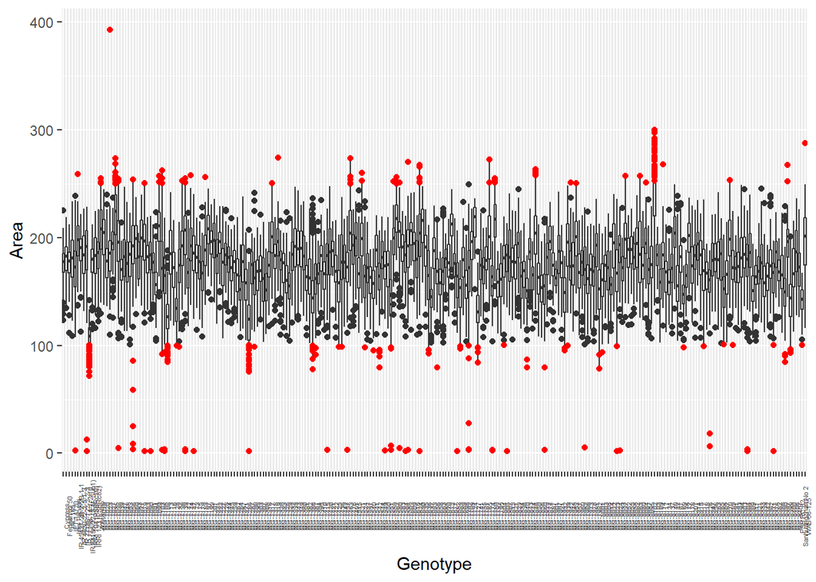

```r
#visualize the outliers identified with the IQR method on the boxplot using ggplot2
ggplot(ww.area, aes(x=Genotype, y=Area)) +
  geom_boxplot() +
  geom_point(data = outliers, aes(x=Genotype, y=Area), color = 'red') +
  theme(axis.text.x = element_text(angle = 90, size = 4))
```

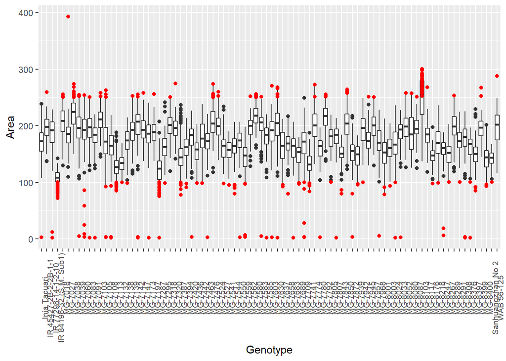

```r
#write.csv(outliers, "WW_Samples_Area_inmm2_outliers.csv", row.names = F)

 #Let's visualize the boxplots of the genotypes with seed outliers for clarity

ww.area.outliers <- ww.area[which(ww.area$Genotype %in% outliers$Genotype),]

#tiff("Boxplot_outliers_1.5IQR_WW_Samples_Feb14_20.tiff")
ggplot(ww.area.outliers, aes(x=Genotype, y=Area)) +
  geom_boxplot() +
  geom_point(data = outliers, aes(x=Genotype, y=Area), color = 'red') +
  theme(axis.text.x = element_text(angle = 90, size = 8))
```

```r
#dev.off()
```

In the above boxplots, the red dots with values of seed area close to zero or below 60, are pieces of the same seed identified as different objects. On the contrary, the red dots above 350 are those seeds that are too close on the scanner during the scanning that they are identified as a single object. Since the IQR method was a bit conservative because removing extreme seed measures with a biological meaning, we decided to use the value 60 and 350 as empirical cutoffs to remove errouneous seed area measures.

```r
ww.metrics.noOut <- ww.metrics[which(ww.metrics$Area > 60 &
                                       ww.metrics$Area < 350),]


ww.geno.all.clean.noOut <- ww.geno.all.clean[which(ww.geno.all.clean$filename %in% ww.metrics.noOut$filename),]
#write.csv(ww.geno.all.clean.noOut, "WW_Samples_ALLPhenotypes_Metrics_mm_Feb14_2020_noOut.csv", row.names = F)
```

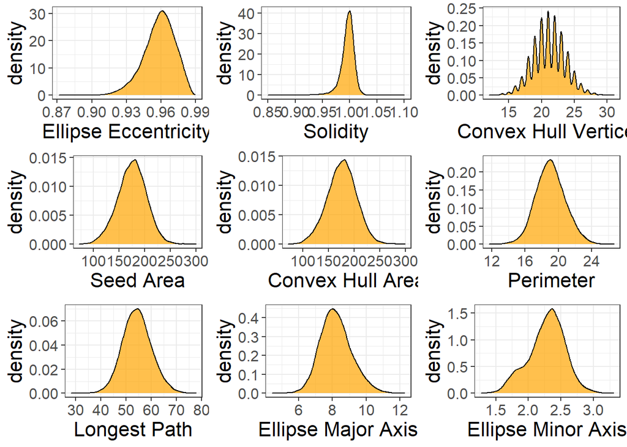

```r
p2 <- ggplot(ww.metrics.noOut, aes(x = Eccentricity)) +
  geom_density(fill = "orange", alpha = 0.7) + xlab("Ellipse Eccentricity") + theme_bw() +
  theme(axis.title = element_text(size = 16),
        axis.text = element_text(size = 12))

p3 <- ggplot(ww.metrics.noOut, aes(x = Solidity)) +
  geom_density(fill = "orange", alpha = 0.7) + xlab("Solidity") + xlim(c(0.85, 1.1)) +
  theme_bw() +
  theme(axis.title = element_text(size = 16),
        axis.text = element_text(size = 12))

p4 <- ggplot(ww.metrics.noOut, aes(x = CH.Vertices)) +
  geom_density(fill = "orange", alpha = 0.7) + xlab("Convex Hull Vertices") + theme_bw() +
  theme(axis.title = element_text(size = 16),
        axis.text = element_text(size = 12))

p5 <- ggplot(ww.metrics.noOut, aes(x = Area)) +
  geom_density(fill = "orange", alpha = 0.7) + xlab("Seed Area") + theme_bw() +
  theme(axis.title = element_text(size = 16),
        axis.text = element_text(size = 12))

p6 <- ggplot(ww.metrics.noOut, aes(x = CH.Area)) +
  geom_density(fill = "orange", alpha = 0.7) + xlab("Convex Hull Area") + theme_bw() +
  theme(axis.title = element_text(size = 16),
        axis.text = element_text(size = 12))

p7 <- ggplot(ww.metrics.noOut, aes(x = Perimeter)) +
  geom_density(fill = "orange", alpha = 0.7) + xlab("Perimeter") + theme_bw() +
  theme(axis.title = element_text(size = 16),
        axis.text = element_text(size = 12))

p10 <- ggplot(ww.metrics.noOut, aes(x = Longest.Path)) +
  geom_density(fill = "orange", alpha = 0.7) + xlab("Longest Path") + theme_bw() +
  theme(axis.title = element_text(size = 16),
        axis.text = element_text(size = 12))

p11 <- ggplot(ww.metrics.noOut, aes(x = Major.Axis)) +
  geom_density(fill = "orange", alpha = 0.7) + xlab("Ellipse Major Axis") + theme_bw() +
  theme(axis.title = element_text(size = 16),
        axis.text = element_text(size = 12))

p12 <- ggplot(ww.metrics.noOut, aes(x = Minor.Axis)) +
  geom_density(fill = "orange", alpha = 0.7) + xlab("Ellipse Minor Axis") + theme_bw() +
  theme(axis.title = element_text(size = 16),
        axis.text = element_text(size = 12))

#tiff("WW_Trait_Distributions.tiff", res = 300, height = 25, width = 25, units = "cm")
grid.arrange(p2, p3, p4, p5, p6, p7, p10, p11, p12, ncol= 3)
```

```r
#dev.off()
```

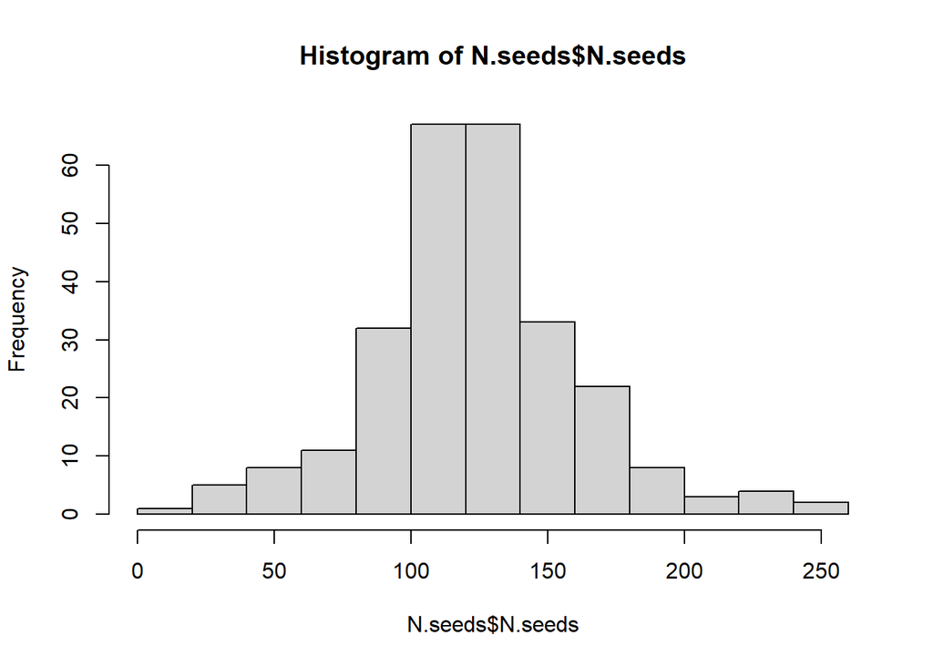

```r
ds.metrics <- ds.geno.all.clean %>%
  select(-c(Seed_ID, image, timestamp, ellipse_minor_axis, ellipse_major_axis, area, convex_hull_area, perimeter, longest_path))

#write.csv(ds.metrics, "DS_Samples_onlyPheno_Converted_mm_Feb14_2020.csv", row.names = F)

N.seeds <- data.frame(table(ds.metrics$Label_Phenotyping))
colnames(N.seeds) <- c("Label_Phenotyping", "N.seeds")
hist(N.seeds$N.seeds)
```

```r
summary(N.seeds$N.seeds)
```

```
##    Min. 1st Qu.  Median    Mean 3rd Qu.    Max.
##    15.0   104.0   122.0   124.7   144.5   251.0
```

```r
#(95% confidence interval)

N.seeds.CI.ww <- N.seeds %>%
  summarise(mean = mean(N.seeds, na.rm = TRUE),
            sd = sd(N.seeds, na.rm = TRUE),
            n = n()) %>%
  mutate(se = sd / sqrt(n),
         lower.ci = mean - qt(1 - (0.05 / 2), n - 1) * se,
         upper.ci = mean + qt(1 - (0.05 / 2), n - 1) * se)

N.seeds.CI.ww
```

| mean | sd | n | se | lower.ci | upper.ci |
| --- | --- | --- | --- | --- | --- |
| 124.7034 | 37.78075 | 263 | 2.329661 | 120.1162 | 129.2907 |

```r
summary(ds.metrics$Area)
```

```
##    Min. 1st Qu.  Median    Mean 3rd Qu.    Max.
##   2.125 122.825 141.100 140.890 159.035 380.120
```

```r
#identify outliers using the boxplot.stats function
outlier_values <- boxplot.stats(ds.metrics$area_inmm2)$out  # outlier values.
length(outlier_values)#438
```

```
## [1] 0
```

```r
max(outlier_values)
```

```
## [1] -Inf
```

```r
min(outlier_values)
```

```
## [1] Inf
```

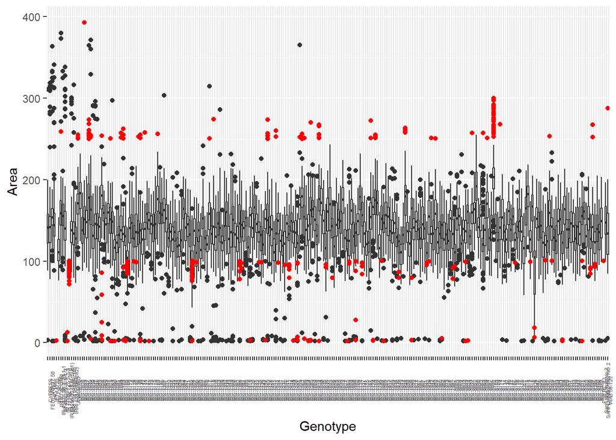

```r
#Interquartile Range method (IQR)
minT <- summary(ds.metrics$Area)[2] - 1.5*IQR(ds.metrics$Area)#68.5
maxT <- summary(ds.metrics$Area)[5] + 1.5*IQR(ds.metrics$Area)#213

ds.area <- ds.metrics %>%
  select(Label_Phenotyping, Genotype, Area)

ds.area$outlier <- "No"

ds.area$outlier[ds.area$Area <= minT | ds.area$Area >= maxT] <- "Yes"

#visualize the outliers identified with the IQR method on the boxplot using ggplot2
ggplot(ds.area, aes(x=Genotype, y=Area)) +
  geom_boxplot() +
  geom_point(data = outliers, aes(x=Genotype, y=Area), color = 'red') +
  theme(axis.text.x = element_text(angle = 90, size = 4))
```

```r
outliers <- ds.area[which(ds.area$outlier == "Yes"),]
length(unique(outliers$Genotype))#145
```

```
## [1] 145
```

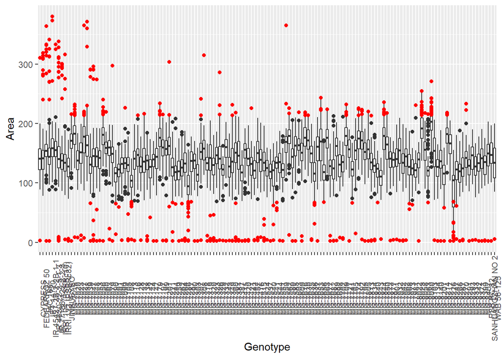

```r
#write.csv(outliers, "DS_Samples_Area_inmm2_outliers.csv", row.names = F)


#Let's visualize the boxplots of the genotypes with seed outliers for clarity

ds.area.outliers <- ds.area[which(ds.area$Genotype %in% outliers$Genotype),]

#tiff("Boxplot_outliers_1.5IQR_WW_Samples_Feb14_20.tiff")
ggplot(ds.area.outliers, aes(x=Genotype, y=Area)) +
  geom_boxplot() +
  geom_point(data = outliers, aes(x=Genotype, y=Area), color = 'red') +
  theme(axis.text.x = element_text(angle = 90, size = 8))
```

```r
#dev.off()
```

In the case of drought stressed samples (DS), I used different values of cutoffs (<30 and > 350). In addition, I checked single images to confirm that they were true outliers and refined the final list of sample seeds to remove.

```r
ds.metrics.Out <- ds.metrics[which(ds.metrics$Area > 30 &
                                       ds.metrics$Area < 350),]

#write.csv(ds.metrics.Out, "DS_Samples_Area_inmm2_outliers.csv", row.names = F)

##After checking the single images, I refined the list of outliers to remove:

outliers_toRemove <- read.csv("DS_Samples_Area_inmm2_outliers_toRemove.csv")

ds.geno.all.clean.noOut <- ds.geno.all.clean[which(!ds.geno.all.clean$filename %in% outliers_toRemove$filename),]
ds.metrics.noOut <- ds.metrics[which(!ds.metrics$filename %in% outliers_toRemove$filename),]


#write.csv(ds.geno.all.clean.noOut, "DS_Samples_ALLPhenotypes_Metrics_mm_Feb14_2020_noOut.csv", row.names = F)
```

```r
all.seeds.metrics <- rbind(ww.metrics.noOut, ds.metrics.noOut)

#all.seeds.metrics <- read.csv("All.seeds.metrics_noOut.csv")
```

```r
#I let's addplots and block information per sample and environment


info.rep.plot.filt <- read.csv("Info.Rep.Plot.filter_DEF.csv")

info.rep.plot.filt.cut <- info.rep.plot.filt %>%
  select(-c(Genotype))


all.seeds.metrics.edit <- left_join(all.seeds.metrics, info.rep.plot.filt.cut)
#add block info

block <- read.csv("../../rice-phenotyping/Block_Info.csv")

block <- block %>%
  rename(Plot = Plot.) %>%
  mutate(Block.edit = paste0(tolower(Environment), "-", Block))


all.seeds.metrics.edit.block <- left_join(all.seeds.metrics.edit, block)
#write.csv(all.seeds.metrics.edit.block, "All.seeds.metrics_noOut.Plot.Block.csv", row.names = F)
```

```r
# The gold-standard, traditional cross-classified ANOVA for GxE would be to model a rep + genotype + enviroment + genotype x enviroment. Rep is a nuisance variable. Further, the reasoning behind not fitting the model for an augmented design was bit unclear to me as well, but not a concern if the rep effect was not significant.

eccentricity.norm <- lm(all.seeds.metrics.edit.block$Eccentricity ~ all.seeds.metrics.edit.block$Genotype + all.seeds.metrics.edit.block$Environment + all.seeds.metrics.edit.block$Block.edit + all.seeds.metrics.edit.block$Genotype:all.seeds.metrics.edit.block$Environment)

#the shapiro.test works with max 5000 observations!
#let's try the Anderson-Darling normality test
ad.test(eccentricity.norm$residuals)
```

```
##
##  Anderson-Darling normality test
##
## data:  eccentricity.norm$residuals
## A = 138.01, p-value < 2.2e-16
```

```r
eccentricity.aov <- aov(eccentricity.norm)
summary(eccentricity.aov)
```

```
##                                                                                   Df
## all.seeds.metrics.edit.block$Genotype                                            257
## all.seeds.metrics.edit.block$Environment                                           1
## all.seeds.metrics.edit.block$Block.edit                                            6
## all.seeds.metrics.edit.block$Genotype:all.seeds.metrics.edit.block$Environment   249
## Residuals                                                                      57454
##                                                                                Sum Sq
## all.seeds.metrics.edit.block$Genotype                                           4.121
## all.seeds.metrics.edit.block$Environment                                        0.046
## all.seeds.metrics.edit.block$Block.edit                                         0.030
## all.seeds.metrics.edit.block$Genotype:all.seeds.metrics.edit.block$Environment  0.945
## Residuals                                                                       5.942
##                                                                                Mean Sq
## all.seeds.metrics.edit.block$Genotype                                          0.01603
## all.seeds.metrics.edit.block$Environment                                       0.04573
## all.seeds.metrics.edit.block$Block.edit                                        0.00495
## all.seeds.metrics.edit.block$Genotype:all.seeds.metrics.edit.block$Environment 0.00380
## Residuals                                                                      0.00010
##                                                                                F value
## all.seeds.metrics.edit.block$Genotype                                           155.02
## all.seeds.metrics.edit.block$Environment                                        442.12
## all.seeds.metrics.edit.block$Block.edit                                          47.83
## all.seeds.metrics.edit.block$Genotype:all.seeds.metrics.edit.block$Environment   36.71
## Residuals
##                                                                                Pr(>F)
## all.seeds.metrics.edit.block$Genotype                                          <2e-16
## all.seeds.metrics.edit.block$Environment                                       <2e-16
## all.seeds.metrics.edit.block$Block.edit                                        <2e-16
## all.seeds.metrics.edit.block$Genotype:all.seeds.metrics.edit.block$Environment <2e-16
## Residuals
##
## all.seeds.metrics.edit.block$Genotype                                          ***
## all.seeds.metrics.edit.block$Environment                                       ***
## all.seeds.metrics.edit.block$Block.edit                                        ***
## all.seeds.metrics.edit.block$Genotype:all.seeds.metrics.edit.block$Environment ***
## Residuals
## ---
## Signif. codes:  0 '***' 0.001 '**' 0.01 '*' 0.05 '.' 0.1 ' ' 1
## 700 observations deleted due to missingness
```

```r
###

solidity.norm <- lm(all.seeds.metrics.edit.block$Solidity ~ all.seeds.metrics.edit.block$Genotype + all.seeds.metrics.edit.block$Environment + all.seeds.metrics.edit.block$Block.edit + all.seeds.metrics.edit.block$Genotype:all.seeds.metrics.edit.block$Environment)

ad.test(solidity.norm$residuals)
```

```
##
##  Anderson-Darling normality test
##
## data:  solidity.norm$residuals
## A = 1143.8, p-value < 2.2e-16
```

```r
solidity.aov <- aov(solidity.norm)
summary(solidity.aov)
```

```
##                                                                                   Df
## all.seeds.metrics.edit.block$Genotype                                            257
## all.seeds.metrics.edit.block$Environment                                           1
## all.seeds.metrics.edit.block$Block.edit                                            6
## all.seeds.metrics.edit.block$Genotype:all.seeds.metrics.edit.block$Environment   249
## Residuals                                                                      57454
##                                                                                Sum Sq
## all.seeds.metrics.edit.block$Genotype                                           1.925
## all.seeds.metrics.edit.block$Environment                                        0.012
## all.seeds.metrics.edit.block$Block.edit                                         0.055
## all.seeds.metrics.edit.block$Genotype:all.seeds.metrics.edit.block$Environment  0.574
## Residuals                                                                      12.806
##                                                                                 Mean Sq
## all.seeds.metrics.edit.block$Genotype                                          0.007491
## all.seeds.metrics.edit.block$Environment                                       0.011760
## all.seeds.metrics.edit.block$Block.edit                                        0.009226
## all.seeds.metrics.edit.block$Genotype:all.seeds.metrics.edit.block$Environment 0.002305
## Residuals                                                                      0.000223
##                                                                                F value
## all.seeds.metrics.edit.block$Genotype                                            33.60
## all.seeds.metrics.edit.block$Environment                                         52.76
## all.seeds.metrics.edit.block$Block.edit                                          41.39
## all.seeds.metrics.edit.block$Genotype:all.seeds.metrics.edit.block$Environment   10.34
## Residuals
##                                                                                  Pr(>F)
## all.seeds.metrics.edit.block$Genotype                                           < 2e-16
## all.seeds.metrics.edit.block$Environment                                       3.82e-13
## all.seeds.metrics.edit.block$Block.edit                                         < 2e-16
## all.seeds.metrics.edit.block$Genotype:all.seeds.metrics.edit.block$Environment  < 2e-16
## Residuals
##
## all.seeds.metrics.edit.block$Genotype                                          ***
## all.seeds.metrics.edit.block$Environment                                       ***
## all.seeds.metrics.edit.block$Block.edit                                        ***
## all.seeds.metrics.edit.block$Genotype:all.seeds.metrics.edit.block$Environment ***
## Residuals
## ---
## Signif. codes:  0 '***' 0.001 '**' 0.01 '*' 0.05 '.' 0.1 ' ' 1
## 700 observations deleted due to missingness
```

```r
###

chvertices.norm <- lm(all.seeds.metrics.edit.block$CH.Vertices ~ all.seeds.metrics.edit.block$Genotype + all.seeds.metrics.edit.block$Environment + all.seeds.metrics.edit.block$Block.edit + all.seeds.metrics.edit.block$Genotype:all.seeds.metrics.edit.block$Environment)

ad.test(chvertices.norm$residuals)
```

```
##
##  Anderson-Darling normality test
##
## data:  chvertices.norm$residuals
## A = 3.1249, p-value = 7.811e-08
```

```r
chvertices.aov <- aov(chvertices.norm)
summary(chvertices.aov)
```

```
##                                                                                   Df
## all.seeds.metrics.edit.block$Genotype                                            257
## all.seeds.metrics.edit.block$Environment                                           1
## all.seeds.metrics.edit.block$Block.edit                                            6
## all.seeds.metrics.edit.block$Genotype:all.seeds.metrics.edit.block$Environment   249
## Residuals                                                                      57454
##                                                                                Sum Sq
## all.seeds.metrics.edit.block$Genotype                                           29169
## all.seeds.metrics.edit.block$Environment                                        29485
## all.seeds.metrics.edit.block$Block.edit                                           792
## all.seeds.metrics.edit.block$Genotype:all.seeds.metrics.edit.block$Environment   9191
## Residuals                                                                      302456
##                                                                                Mean Sq
## all.seeds.metrics.edit.block$Genotype                                              113
## all.seeds.metrics.edit.block$Environment                                         29485
## all.seeds.metrics.edit.block$Block.edit                                            132
## all.seeds.metrics.edit.block$Genotype:all.seeds.metrics.edit.block$Environment      37
## Residuals                                                                            5
##                                                                                 F value
## all.seeds.metrics.edit.block$Genotype                                            21.560
## all.seeds.metrics.edit.block$Environment                                       5600.930
## all.seeds.metrics.edit.block$Block.edit                                          25.085
## all.seeds.metrics.edit.block$Genotype:all.seeds.metrics.edit.block$Environment    7.012
## Residuals
##                                                                                Pr(>F)
## all.seeds.metrics.edit.block$Genotype                                          <2e-16
## all.seeds.metrics.edit.block$Environment                                       <2e-16
## all.seeds.metrics.edit.block$Block.edit                                        <2e-16
## all.seeds.metrics.edit.block$Genotype:all.seeds.metrics.edit.block$Environment <2e-16
## Residuals
##
## all.seeds.metrics.edit.block$Genotype                                          ***
## all.seeds.metrics.edit.block$Environment                                       ***
## all.seeds.metrics.edit.block$Block.edit                                        ***
## all.seeds.metrics.edit.block$Genotype:all.seeds.metrics.edit.block$Environment ***
## Residuals
## ---
## Signif. codes:  0 '***' 0.001 '**' 0.01 '*' 0.05 '.' 0.1 ' ' 1
## 700 observations deleted due to missingness
```

```r
###

area.norm <- lm(all.seeds.metrics.edit.block$Area ~ all.seeds.metrics.edit.block$Genotype + all.seeds.metrics.edit.block$Environment + all.seeds.metrics.edit.block$Block.edit + all.seeds.metrics.edit.block$Genotype:all.seeds.metrics.edit.block$Environment)

ad.test(area.norm$residuals)
```

```
##
##  Anderson-Darling normality test
##
## data:  area.norm$residuals
## A = 95.05, p-value < 2.2e-16
```

```r
chvertices.aov <- aov(area.norm)
summary(chvertices.aov)
```

```
##                                                                                   Df
## all.seeds.metrics.edit.block$Genotype                                            257
## all.seeds.metrics.edit.block$Environment                                           1
## all.seeds.metrics.edit.block$Block.edit                                            6
## all.seeds.metrics.edit.block$Genotype:all.seeds.metrics.edit.block$Environment   249
## Residuals                                                                      57454
##                                                                                  Sum Sq
## all.seeds.metrics.edit.block$Genotype                                          11752092
## all.seeds.metrics.edit.block$Environment                                       17021200
## all.seeds.metrics.edit.block$Block.edit                                          129392
## all.seeds.metrics.edit.block$Genotype:all.seeds.metrics.edit.block$Environment  2791351
## Residuals                                                                      26902078
##                                                                                 Mean Sq
## all.seeds.metrics.edit.block$Genotype                                             45728
## all.seeds.metrics.edit.block$Environment                                       17021200
## all.seeds.metrics.edit.block$Block.edit                                           21565
## all.seeds.metrics.edit.block$Genotype:all.seeds.metrics.edit.block$Environment    11210
## Residuals                                                                           468
##                                                                                 F value
## all.seeds.metrics.edit.block$Genotype                                             97.66
## all.seeds.metrics.edit.block$Environment                                       36351.69
## all.seeds.metrics.edit.block$Block.edit                                           46.06
## all.seeds.metrics.edit.block$Genotype:all.seeds.metrics.edit.block$Environment    23.94
## Residuals
##                                                                                Pr(>F)
## all.seeds.metrics.edit.block$Genotype                                          <2e-16
## all.seeds.metrics.edit.block$Environment                                       <2e-16
## all.seeds.metrics.edit.block$Block.edit                                        <2e-16
## all.seeds.metrics.edit.block$Genotype:all.seeds.metrics.edit.block$Environment <2e-16
## Residuals
##
## all.seeds.metrics.edit.block$Genotype                                          ***
## all.seeds.metrics.edit.block$Environment                                       ***
## all.seeds.metrics.edit.block$Block.edit                                        ***
## all.seeds.metrics.edit.block$Genotype:all.seeds.metrics.edit.block$Environment ***
## Residuals
## ---
## Signif. codes:  0 '***' 0.001 '**' 0.01 '*' 0.05 '.' 0.1 ' ' 1
## 700 observations deleted due to missingness
```

```r
###

charea.norm <- lm(all.seeds.metrics.edit.block$CH.Area ~ all.seeds.metrics.edit.block$Genotype + all.seeds.metrics.edit.block$Environment + all.seeds.metrics.edit.block$Block.edit + all.seeds.metrics.edit.block$Genotype:all.seeds.metrics.edit.block$Environment)

ad.test(charea.norm$residuals)
```

```
##
##  Anderson-Darling normality test
##
## data:  charea.norm$residuals
## A = 89.314, p-value < 2.2e-16
```

```r
charea.aov <- aov(charea.norm)
summary(charea.aov)
```

```
##                                                                                   Df
## all.seeds.metrics.edit.block$Genotype                                            257
## all.seeds.metrics.edit.block$Environment                                           1
## all.seeds.metrics.edit.block$Block.edit                                            6
## all.seeds.metrics.edit.block$Genotype:all.seeds.metrics.edit.block$Environment   249
## Residuals                                                                      57454
##                                                                                  Sum Sq
## all.seeds.metrics.edit.block$Genotype                                          12128993
## all.seeds.metrics.edit.block$Environment                                       17062796
## all.seeds.metrics.edit.block$Block.edit                                          120015
## all.seeds.metrics.edit.block$Genotype:all.seeds.metrics.edit.block$Environment  2839130
## Residuals                                                                      27519797
##                                                                                 Mean Sq
## all.seeds.metrics.edit.block$Genotype                                             47195
## all.seeds.metrics.edit.block$Environment                                       17062796
## all.seeds.metrics.edit.block$Block.edit                                           20002
## all.seeds.metrics.edit.block$Genotype:all.seeds.metrics.edit.block$Environment    11402
## Residuals                                                                           479
##                                                                                 F value
## all.seeds.metrics.edit.block$Genotype                                             98.53
## all.seeds.metrics.edit.block$Environment                                       35622.57
## all.seeds.metrics.edit.block$Block.edit                                           41.76
## all.seeds.metrics.edit.block$Genotype:all.seeds.metrics.edit.block$Environment    23.80
## Residuals
##                                                                                Pr(>F)
## all.seeds.metrics.edit.block$Genotype                                          <2e-16
## all.seeds.metrics.edit.block$Environment                                       <2e-16
## all.seeds.metrics.edit.block$Block.edit                                        <2e-16
## all.seeds.metrics.edit.block$Genotype:all.seeds.metrics.edit.block$Environment <2e-16
## Residuals
##
## all.seeds.metrics.edit.block$Genotype                                          ***
## all.seeds.metrics.edit.block$Environment                                       ***
## all.seeds.metrics.edit.block$Block.edit                                        ***
## all.seeds.metrics.edit.block$Genotype:all.seeds.metrics.edit.block$Environment ***
## Residuals
## ---
## Signif. codes:  0 '***' 0.001 '**' 0.01 '*' 0.05 '.' 0.1 ' ' 1
## 700 observations deleted due to missingness
```

```r
###

perimeter.norm <- lm(all.seeds.metrics.edit.block$Perimeter ~ all.seeds.metrics.edit.block$Genotype + all.seeds.metrics.edit.block$Environment + all.seeds.metrics.edit.block$Block.edit + all.seeds.metrics.edit.block$Genotype:all.seeds.metrics.edit.block$Environment)

ad.test(perimeter.norm$residuals)
```

```
##
##  Anderson-Darling normality test
##
## data:  perimeter.norm$residuals
## A = 44.367, p-value < 2.2e-16
```

```r
perimeter.aov <- aov(perimeter.norm)
summary(perimeter.aov)
```

```
##                                                                                   Df
## all.seeds.metrics.edit.block$Genotype                                            257
## all.seeds.metrics.edit.block$Environment                                           1
## all.seeds.metrics.edit.block$Block.edit                                            6
## all.seeds.metrics.edit.block$Genotype:all.seeds.metrics.edit.block$Environment   249
## Residuals                                                                      57454
##                                                                                Sum Sq
## all.seeds.metrics.edit.block$Genotype                                           65643
## all.seeds.metrics.edit.block$Environment                                        50314
## all.seeds.metrics.edit.block$Block.edit                                           289
## all.seeds.metrics.edit.block$Genotype:all.seeds.metrics.edit.block$Environment  13616
## Residuals                                                                       90553
##                                                                                Mean Sq
## all.seeds.metrics.edit.block$Genotype                                              255
## all.seeds.metrics.edit.block$Environment                                         50314
## all.seeds.metrics.edit.block$Block.edit                                             48
## all.seeds.metrics.edit.block$Genotype:all.seeds.metrics.edit.block$Environment      55
## Residuals                                                                            2
##                                                                                 F value
## all.seeds.metrics.edit.block$Genotype                                            162.06
## all.seeds.metrics.edit.block$Environment                                       31922.82
## all.seeds.metrics.edit.block$Block.edit                                           30.56
## all.seeds.metrics.edit.block$Genotype:all.seeds.metrics.edit.block$Environment    34.70
## Residuals
##                                                                                Pr(>F)
## all.seeds.metrics.edit.block$Genotype                                          <2e-16
## all.seeds.metrics.edit.block$Environment                                       <2e-16
## all.seeds.metrics.edit.block$Block.edit                                        <2e-16
## all.seeds.metrics.edit.block$Genotype:all.seeds.metrics.edit.block$Environment <2e-16
## Residuals
##
## all.seeds.metrics.edit.block$Genotype                                          ***
## all.seeds.metrics.edit.block$Environment                                       ***
## all.seeds.metrics.edit.block$Block.edit                                        ***
## all.seeds.metrics.edit.block$Genotype:all.seeds.metrics.edit.block$Environment ***
## Residuals
## ---
## Signif. codes:  0 '***' 0.001 '**' 0.01 '*' 0.05 '.' 0.1 ' ' 1
## 700 observations deleted due to missingness
```

```r
###

longestpath.norm <- lm(all.seeds.metrics.edit.block$Longest.Path ~ all.seeds.metrics.edit.block$Genotype + all.seeds.metrics.edit.block$Environment + all.seeds.metrics.edit.block$Block.edit + all.seeds.metrics.edit.block$Genotype:all.seeds.metrics.edit.block$Environment)

ad.test(longestpath.norm$residuals)
```

```
##
##  Anderson-Darling normality test
##
## data:  longestpath.norm$residuals
## A = 15.063, p-value < 2.2e-16
```

```r
longestpath.aov <- aov(longestpath.norm)
summary(longestpath.aov)
```

```
##                                                                                   Df
## all.seeds.metrics.edit.block$Genotype                                            257
## all.seeds.metrics.edit.block$Environment                                           1
## all.seeds.metrics.edit.block$Block.edit                                            6
## all.seeds.metrics.edit.block$Genotype:all.seeds.metrics.edit.block$Environment   249
## Residuals                                                                      57454
##                                                                                 Sum Sq
## all.seeds.metrics.edit.block$Genotype                                           611592
## all.seeds.metrics.edit.block$Environment                                        411400
## all.seeds.metrics.edit.block$Block.edit                                           2849
## all.seeds.metrics.edit.block$Genotype:all.seeds.metrics.edit.block$Environment  126884
## Residuals                                                                      1025628
##                                                                                Mean Sq
## all.seeds.metrics.edit.block$Genotype                                             2380
## all.seeds.metrics.edit.block$Environment                                        411400
## all.seeds.metrics.edit.block$Block.edit                                            475
## all.seeds.metrics.edit.block$Genotype:all.seeds.metrics.edit.block$Environment     510
## Residuals                                                                           18
##                                                                                 F value
## all.seeds.metrics.edit.block$Genotype                                            133.31
## all.seeds.metrics.edit.block$Environment                                       23045.94
## all.seeds.metrics.edit.block$Block.edit                                           26.60
## all.seeds.metrics.edit.block$Genotype:all.seeds.metrics.edit.block$Environment    28.55
## Residuals
##                                                                                Pr(>F)
## all.seeds.metrics.edit.block$Genotype                                          <2e-16
## all.seeds.metrics.edit.block$Environment                                       <2e-16
## all.seeds.metrics.edit.block$Block.edit                                        <2e-16
## all.seeds.metrics.edit.block$Genotype:all.seeds.metrics.edit.block$Environment <2e-16
## Residuals
##
## all.seeds.metrics.edit.block$Genotype                                          ***
## all.seeds.metrics.edit.block$Environment                                       ***
## all.seeds.metrics.edit.block$Block.edit                                        ***
## all.seeds.metrics.edit.block$Genotype:all.seeds.metrics.edit.block$Environment ***
## Residuals
## ---
## Signif. codes:  0 '***' 0.001 '**' 0.01 '*' 0.05 '.' 0.1 ' ' 1
## 700 observations deleted due to missingness
```

```r
###

majorA.norm <- lm(all.seeds.metrics.edit.block$Major.Axis ~ all.seeds.metrics.edit.block$Genotype + all.seeds.metrics.edit.block$Environment + all.seeds.metrics.edit.block$Block.edit + all.seeds.metrics.edit.block$Genotype:all.seeds.metrics.edit.block$Environment)

ad.test(majorA.norm$residuals)
```

```
##
##  Anderson-Darling normality test
##
## data:  majorA.norm$residuals
## A = 72.336, p-value < 2.2e-16
```

```r
majorA.aov <- aov(majorA.norm)
summary(majorA.aov)
```

```
##                                                                                   Df
## all.seeds.metrics.edit.block$Genotype                                            257
## all.seeds.metrics.edit.block$Environment                                           1
## all.seeds.metrics.edit.block$Block.edit                                            6
## all.seeds.metrics.edit.block$Genotype:all.seeds.metrics.edit.block$Environment   249
## Residuals                                                                      57454
##                                                                                Sum Sq
## all.seeds.metrics.edit.block$Genotype                                           18923
## all.seeds.metrics.edit.block$Environment                                         9097
## all.seeds.metrics.edit.block$Block.edit                                            90
## all.seeds.metrics.edit.block$Genotype:all.seeds.metrics.edit.block$Environment   4024
## Residuals                                                                       22646
##                                                                                Mean Sq
## all.seeds.metrics.edit.block$Genotype                                               74
## all.seeds.metrics.edit.block$Environment                                          9097
## all.seeds.metrics.edit.block$Block.edit                                             15
## all.seeds.metrics.edit.block$Genotype:all.seeds.metrics.edit.block$Environment      16
## Residuals                                                                            0
##                                                                                 F value
## all.seeds.metrics.edit.block$Genotype                                            186.81
## all.seeds.metrics.edit.block$Environment                                       23081.22
## all.seeds.metrics.edit.block$Block.edit                                           38.08
## all.seeds.metrics.edit.block$Genotype:all.seeds.metrics.edit.block$Environment    41.01
## Residuals
##                                                                                Pr(>F)
## all.seeds.metrics.edit.block$Genotype                                          <2e-16
## all.seeds.metrics.edit.block$Environment                                       <2e-16
## all.seeds.metrics.edit.block$Block.edit                                        <2e-16
## all.seeds.metrics.edit.block$Genotype:all.seeds.metrics.edit.block$Environment <2e-16
## Residuals
##
## all.seeds.metrics.edit.block$Genotype                                          ***
## all.seeds.metrics.edit.block$Environment                                       ***
## all.seeds.metrics.edit.block$Block.edit                                        ***
## all.seeds.metrics.edit.block$Genotype:all.seeds.metrics.edit.block$Environment ***
## Residuals
## ---
## Signif. codes:  0 '***' 0.001 '**' 0.01 '*' 0.05 '.' 0.1 ' ' 1
## 700 observations deleted due to missingness
```

```r
###

minorA.norm <- lm(all.seeds.metrics.edit.block$Minor.Axis ~ all.seeds.metrics.edit.block$Genotype + all.seeds.metrics.edit.block$Environment + all.seeds.metrics.edit.block$Block.edit + all.seeds.metrics.edit.block$Genotype:all.seeds.metrics.edit.block$Environment)

ad.test(minorA.norm$residuals)
```

```
##
##  Anderson-Darling normality test
##
## data:  minorA.norm$residuals
## A = 417.96, p-value < 2.2e-16
```

```r
minorA.aov <- aov(minorA.norm)
summary(minorA.aov)
```

```
##                                                                                   Df
## all.seeds.metrics.edit.block$Genotype                                            257
## all.seeds.metrics.edit.block$Environment                                           1
## all.seeds.metrics.edit.block$Block.edit                                            6
## all.seeds.metrics.edit.block$Genotype:all.seeds.metrics.edit.block$Environment   249
## Residuals                                                                      57454
##                                                                                Sum Sq
## all.seeds.metrics.edit.block$Genotype                                            1207
## all.seeds.metrics.edit.block$Environment                                          991
## all.seeds.metrics.edit.block$Block.edit                                            18
## all.seeds.metrics.edit.block$Genotype:all.seeds.metrics.edit.block$Environment    315
## Residuals                                                                        3184
##                                                                                Mean Sq
## all.seeds.metrics.edit.block$Genotype                                              4.7
## all.seeds.metrics.edit.block$Environment                                         990.7
## all.seeds.metrics.edit.block$Block.edit                                            3.1
## all.seeds.metrics.edit.block$Genotype:all.seeds.metrics.edit.block$Environment     1.3
## Residuals                                                                          0.1
##                                                                                 F value
## all.seeds.metrics.edit.block$Genotype                                             84.74
## all.seeds.metrics.edit.block$Environment                                       17876.00
## all.seeds.metrics.edit.block$Block.edit                                           55.43
## all.seeds.metrics.edit.block$Genotype:all.seeds.metrics.edit.block$Environment    22.83
## Residuals
##                                                                                Pr(>F)
## all.seeds.metrics.edit.block$Genotype                                          <2e-16
## all.seeds.metrics.edit.block$Environment                                       <2e-16
## all.seeds.metrics.edit.block$Block.edit                                        <2e-16
## all.seeds.metrics.edit.block$Genotype:all.seeds.metrics.edit.block$Environment <2e-16
## Residuals
##
## all.seeds.metrics.edit.block$Genotype                                          ***
## all.seeds.metrics.edit.block$Environment                                       ***
## all.seeds.metrics.edit.block$Block.edit                                        ***
## all.seeds.metrics.edit.block$Genotype:all.seeds.metrics.edit.block$Environment ***
## Residuals
## ---
## Signif. codes:  0 '***' 0.001 '**' 0.01 '*' 0.05 '.' 0.1 ' ' 1
## 700 observations deleted due to missingness
```

```r
#first let's create two dataframes based on the Environments

ww.seeds.metrics.edit.block <- all.seeds.metrics.edit.block %>%
  filter(Environment == "WW")

ds.seeds.metrics.edit.block <- all.seeds.metrics.edit.block %>%
  filter(Environment == "DS")

#Adjusted means for WW
#let's fit the model

#eccentricity
ww.eccentricity.lm <- lm(Eccentricity ~ Genotype + Block, data = ww.seeds.metrics.edit.block)

anova(ww.eccentricity.lm)
```

|  | Df | Sum Sq | Mean Sq | F value | Pr(>F) |
| --- | --- | --- | --- | --- | --- |
| Genotype | 255 | 2.5327372329 | 9.932303e-03 | 109.774253 | 0.00000000 |
| Block | 1 | 0.0004384705 | 4.384705e-04 | 4.846084 | 0.02771774 |
| Residuals | 25938 | 2.3468533378 | 9.047935e-05 | NA | NA |

```r
ww.eccentricity.lsm <- as.data.frame(lsmeans(ww.eccentricity.lm, "Genotype"))

#solidity

ww.solidity.lm <- lm(Solidity ~ Genotype + Block, data = ww.seeds.metrics.edit.block)

anova(ww.solidity.lm)
```

|  | Df | Sum Sq | Mean Sq | F value | Pr(>F) |
| --- | --- | --- | --- | --- | --- |
| Genotype | 255 | 1.1579493133 | 0.0045409777 | 30.73069 | 0.00000000 |
| Block | 1 | 0.0009068599 | 0.0009068599 | 6.13710 | 0.01324375 |
| Residuals | 25938 | 3.8327764090 | 0.0001477668 | NA | NA |

```r
ww.solidity.lsm <- as.data.frame(lsmeans(ww.solidity.lm, "Genotype"))

#ch.vertices

ww.ch.vertices.lm <- lm(CH.Vertices ~ Genotype + Block, data = ww.seeds.metrics.edit.block)

anova(ww.ch.vertices.lm)
```

|  | Df | Sum Sq | Mean Sq | F value | Pr(>F) |
| --- | --- | --- | --- | --- | --- |
| Genotype | 255 | 1.789898e+04 | 70.1920866 | 13.0539178 | 0.0000000 |
| Block | 1 | 6.849511e-01 | 0.6849511 | 0.1273832 | 0.7211637 |
| Residuals | 25938 | 1.394710e+05 | 5.3770897 | NA | NA |

```r
ww.ch.vertices.lsm <- as.data.frame(lsmeans(ww.ch.vertices.lm, "Genotype"))

#area

ww.area.lm <- lm(Area ~ Genotype + Block, data = ww.seeds.metrics.edit.block)

anova(ww.area.lm)
```

|  | Df | Sum Sq | Mean Sq | F value | Pr(>F) |
| --- | --- | --- | --- | --- | --- |
| Genotype | 255 | 7410721.430 | 29061.6527 | 57.73165 | 0.00000000 |
| Block | 1 | 2218.992 | 2218.9925 | 4.40808 | 0.03577872 |
| Residuals | 25938 | 13056983.596 | 503.3921 | NA | NA |

```r
ww.area.lsm <- as.data.frame(lsmeans(ww.area.lm, "Genotype"))

#ch.area

ww.ch.area.lm <- lm(CH.Area ~ Genotype + Block, data = ww.seeds.metrics.edit.block)

anova(ww.ch.area.lm)
```

|  | Df | Sum Sq | Mean Sq | F value | Pr(>F) |
| --- | --- | --- | --- | --- | --- |
| Genotype | 255 | 7660205.670 | 30040.022 | 58.337614 | 0.00000000 |
| Block | 1 | 2870.696 | 2870.696 | 5.574881 | 0.01822725 |
| Residuals | 25938 | 13356358.742 | 514.934 | NA | NA |

```r
ww.ch.area.lsm <- as.data.frame(lsmeans(ww.ch.area.lm, "Genotype"))

#perimeter

ww.perimeter.lm <- lm(Perimeter ~ Genotype + Block, data = ww.seeds.metrics.edit.block)

anova(ww.perimeter.lm)
```

|  | Df | Sum Sq | Mean Sq | F value | Pr(>F) |
| --- | --- | --- | --- | --- | --- |
| Genotype | 255 | 40281.984490 | 157.968567 | 100.5095301 | 0.0000000 |
| Block | 1 | 1.323636 | 1.323636 | 0.8421803 | 0.3587825 |
| Residuals | 25938 | 40766.170908 | 1.571677 | NA | NA |

```r
ww.perimeter.lsm <- as.data.frame(lsmeans(ww.perimeter.lm, "Genotype"))

#longest path

ww.longestpath.lm <- lm(Longest.Path ~ Genotype + Block, data = ww.seeds.metrics.edit.block)

anova(ww.longestpath.lm)
```

|  | Df | Sum Sq | Mean Sq | F value | Pr(>F) |
| --- | --- | --- | --- | --- | --- |
| Genotype | 255 | 377233.90008 | 1479.34863 | 81.44906 | 0.00000000 |
| Block | 1 | 73.45645 | 73.45645 | 4.04432 | 0.04433057 |
| Residuals | 25938 | 471108.51723 | 18.16287 | NA | NA |

```r
ww.longestpath.lsm <- as.data.frame(lsmeans(ww.longestpath.lm, "Genotype"))

#major axis

ww.majorA.lm <- lm(Major.Axis ~ Genotype + Block, data = ww.seeds.metrics.edit.block)

anova(ww.majorA.lm)
```

|  | Df | Sum Sq | Mean Sq | F value | Pr(>F) |
| --- | --- | --- | --- | --- | --- |
| Genotype | 255 | 12224.563598 | 47.9394651 | 122.879459 | 0.00000000 |
| Block | 1 | 2.054569 | 2.0545692 | 5.266316 | 0.02174993 |
| Residuals | 25938 | 10119.297886 | 0.3901341 | NA | NA |

```r
ww.majorA.lsm <- as.data.frame(lsmeans(ww.majorA.lm, "Genotype"))

#minor axis

ww.minorA.lm <- lm(Minor.Axis ~ Genotype + Block, data = ww.seeds.metrics.edit.block)

anova(ww.minorA.lm)
```

|  | Df | Sum Sq | Mean Sq | F value | Pr(>F) |
| --- | --- | --- | --- | --- | --- |
| Genotype | 255 | 743.2898098 | 2.91486200 | 58.02189 | 0.0000000000 |
| Block | 1 | 0.7299986 | 0.72999864 | 14.53102 | 0.0001381896 |
| Residuals | 25938 | 1303.0545175 | 0.05023728 | NA | NA |

```r
ww.minorA.lsm <- as.data.frame(lsmeans(ww.minorA.lm, "Genotype"))

#get a unique data.frame with all LSMs

ww.eccentricity.lsm <- ww.eccentricity.lsm %>%
  select(Genotype, lsmean) %>%
  rename(Eccentricity = lsmean)

ww.solidity.lsm <- ww.solidity.lsm %>%
  select(Genotype, lsmean) %>%
  rename(Solidity = lsmean)

ww.ch.vertices.lsm <- ww.ch.vertices.lsm %>%
  select(Genotype, lsmean) %>%
  rename(CH.Vertices = lsmean)

ww.area.lsm <- ww.area.lsm %>%
  select(Genotype, lsmean) %>%
  rename(Area = lsmean)

ww.ch.area.lsm <- ww.ch.area.lsm %>%
  select(Genotype, lsmean) %>%
  rename(CH.Area = lsmean)

ww.perimeter.lsm <- ww.perimeter.lsm %>%
  select(Genotype, lsmean) %>%
  rename(Perimeter = lsmean)

ww.longestpath.lsm <- ww.longestpath.lsm %>%
  select(Genotype, lsmean) %>%
  rename(Longest.Path = lsmean)

ww.majorA.lsm <- ww.majorA.lsm %>%
  select(Genotype, lsmean) %>%
  rename(Major.Axis = lsmean)

ww.minorA.lsm <- ww.minorA.lsm %>%
  select(Genotype, lsmean) %>%
  rename(Minor.Axis = lsmean)

ww.lsm.all <- left_join(ww.eccentricity.lsm, ww.solidity.lsm) %>%
  left_join(ww.ch.vertices.lsm) %>%
  left_join(ww.area.lsm) %>%
  left_join(ww.ch.area.lsm) %>%
  left_join(ww.perimeter.lsm) %>%
  left_join(ww.longestpath.lsm) %>%
  left_join(ww.majorA.lsm) %>%
  left_join(ww.minorA.lsm)
#write.csv(ww.lsm.all, "WW.LSM.csv", row.names = F)

#for Tassel
ww.lsm.all.tassel <- ww.lsm.all %>%
  rename(Taxa = Genotype)

#write.table(ww.lsm.all.tassel, "WW.LSM.Tassel.txt", row.names = F, quote = F, sep = '\t', col.names = T)
```

```r
#eccentricity

ds.eccentricity.lm <- lm(Eccentricity ~ Genotype + Block, data = ds.seeds.metrics.edit.block)

anova(ds.eccentricity.lm)
```

|  | Df | Sum Sq | Mean Sq | F value | Pr(>F) |
| --- | --- | --- | --- | --- | --- |
| Genotype | 251 | 2.544981268 | 0.0101393676 | 88.67794 | 0.000000000 |
| Block | 1 | 0.001156475 | 0.0011564748 | 10.11442 | 0.001472563 |
| Residuals | 31520 | 3.603972747 | 0.0001143392 | NA | NA |